# Exploratory Data Analysis

#### Libraries

```r
library(tidyverse, quietly = TRUE)
library(skimr, quietly = TRUE)
library(statsr, quietly = TRUE)
library(GGally, quietly = TRUE)
library(corrplot, quietly = TRUE)
```

Dataset: https://github.com/fivethirtyeight/data/tree/master/college-majors

| Header | Description |
| --- | --- |
| `Rank` | Rank by median earnings |
| `Major_code` | Major code, FO1DP in ACS PUMS |
| `Major` | Major description |
| `Major_category` | Category of major from Carnevale et al |
| `Total` | Total number of people with major |
| `Sample_size` | Sample size (unweighted) of full-time, year-round ONLY (used for earnings) |
| `Men` | Male graduates |
| `Women` | Female graduates |
| `ShareWomen` | Women as share of total |
| `Employed` | Number employed (ESR == 1 or 2) |
| `Full_time` | Employed 35 hours or more |
| `Part_time` | Employed less than 35 hours |
| `Full_time_year_round` | Employed at least 50 weeks (WKW == 1) and at least 35 hours (WKHP >= 35) |
| `Unemployed` | Number unemployed (ESR == 3) |
| `Unemployment_rate` | Unemployed / (Unemployed + Employed) |
| `Median` | Median earnings of full-time, year-round workers |
| `P25th` | 25th percentile of earnings |
| `P75th` | 75th percentile of earnings |
| `College_jobs` | Number with job requiring a college degree |
| `Non_college_jobs` | Number with job not requiring a college degree |
| `Low_wage_jobs` | Number in low-wage service jobs |

The intent of this section is to go over a practical project, following the steps: loading the dataset, understanding the data, treating missing values, exploring and visualizing, and the analysis report.

# 1 Loading the dataset

To continue we need the libraries mentioned before:

- `tidyverse` : eight libraries included, to work with data
- `skimr` : descriptive statistics
- `statsr` : statistical tools and data sampling
- `GGally` : for pair plots
- `corrplot` : correlation plots

```r
# Reading a csv from a web
url <- "https://raw.githubusercontent.com/fivethirtyeight/data/master/college-majors/recent-grads.csv"

df <- read_csv(url)
df.original <- df
```

We’ll keep a copy of the original data frame just in case we need to recover some columns or for comparison reasons.

# 2 Understanding the data

Let’s check the firsts observations:

```r
df %>%
    head()
```

| Rank | Major_code | Major | Total | Men | Women | Major_category | ShareWomen | Sample_size | Employed | Full_time | Part_time | Full_time_year_round | Unemployed | Unemployment_rate | Median | P25th | P75th | College_jobs | Non_college_jobs | Low_wage_jobs |
| --- | --- | --- | --- | --- | --- | --- | --- | --- | --- | --- | --- | --- | --- | --- | --- | --- | --- | --- | --- | --- |
| 1 | 2419 | PETROLEUM ENGINEERING | 2339 | 2057 | 282 | Engineering | 0.1206 | 36 | 1976 | 1849 | 270 | 1207 | 37 | 0.01838 | 110000 | 95000 | 125000 | 1534 | 364 | 193 |
| 2 | 2416 | MINING AND MINERAL ENGINEERING | 756 | 679 | 77 | Engineering | 0.1019 | 7 | 640 | 556 | 170 | 388 | 85 | 0.11724 | 75000 | 55000 | 90000 | 350 | 257 | 50 |
| 3 | 2415 | METALLURGICAL ENGINEERING | 856 | 725 | 131 | Engineering | 0.1530 | 3 | 648 | 558 | 133 | 340 | 16 | 0.02410 | 73000 | 50000 | 105000 | 456 | 176 | 0 |
| 4 | 2417 | NAVAL ARCHITECTURE AND MARINE ENGINEERING | 1258 | 1123 | 135 | Engineering | 0.1073 | 16 | 758 | 1069 | 150 | 692 | 40 | 0.05013 | 70000 | 43000 | 80000 | 529 | 102 | 0 |
| 5 | 2405 | CHEMICAL ENGINEERING | 32260 | 21239 | 11021 | Engineering | 0.3416 | 289 | 25694 | 23170 | 5180 | 16697 | 1672 | 0.06110 | 65000 | 50000 | 75000 | 18314 | 4440 | 972 |
| 6 | 2418 | NUCLEAR ENGINEERING | 2573 | 2200 | 373 | Engineering | 0.1450 | 17 | 1857 | 2038 | 264 | 1449 | 400 | 0.17723 | 65000 | 50000 | 102000 | 1142 | 657 | 244 |

We can see that the data is **rectangular**. At first we do not see any problems with language encoding (strange symbols). And the CSV was read correctly because the columns are fine delimited.

- glimpse(): similar to str(), returns the columns, types and some values.

```r
glimpse(df)
```

```
Rows: 173
Columns: 21
$ Rank                 <dbl> 1, 2, 3, 4, 5, 6, 7, 8, 9, 10, 11, 12, 13, 14, 15, 16, 17, 18…
$ Major_code           <dbl> 2419, 2416, 2415, 2417, 2405, 2418, 6202, 5001, 2414, 2408, 2…
$ Major                <chr> "PETROLEUM ENGINEERING", "MINING AND MINERAL ENGINEERING", "M…
$ Total                <dbl> 2339, 756, 856, 1258, 32260, 2573, 3777, 1792, 91227, 81527, …
$ Men                  <dbl> 2057, 679, 725, 1123, 21239, 2200, 2110, 832, 80320, 65511, 3…
$ Women                <dbl> 282, 77, 131, 135, 11021, 373, 1667, 960, 10907, 16016, 8284,…
$ Major_category       <chr> "Engineering", "Engineering", "Engineering", "Engineering", "…
$ ShareWomen           <dbl> 0.12056, 0.10185, 0.15304, 0.10731, 0.34163, 0.14497, 0.44136…
$ Sample_size          <dbl> 36, 7, 3, 16, 289, 17, 51, 10, 1029, 631, 399, 147, 79, 22, 3…
$ Employed             <dbl> 1976, 640, 648, 758, 25694, 1857, 2912, 1526, 76442, 61928, 3…
$ Full_time            <dbl> 1849, 556, 558, 1069, 23170, 2038, 2924, 1085, 71298, 55450, …
$ Part_time            <dbl> 270, 170, 133, 150, 5180, 264, 296, 553, 13101, 12695, 5146, …
$ Full_time_year_round <dbl> 1207, 388, 340, 692, 16697, 1449, 2482, 827, 54639, 41413, 23…
$ Unemployed           <dbl> 37, 85, 16, 40, 1672, 400, 308, 33, 4650, 3895, 2275, 794, 10…
$ Unemployment_rate    <dbl> 0.018381, 0.117241, 0.024096, 0.050125, 0.061098, 0.177226, 0…
$ Median               <dbl> 110000, 75000, 73000, 70000, 65000, 65000, 62000, 62000, 6000…
$ P25th                <dbl> 95000, 55000, 50000, 43000, 50000, 50000, 53000, 31500, 48000…
$ P75th                <dbl> 125000, 90000, 105000, 80000, 75000, 102000, 72000, 109000, 7…
$ College_jobs         <dbl> 1534, 350, 456, 529, 18314, 1142, 1768, 972, 52844, 45829, 23…
$ Non_college_jobs     <dbl> 364, 257, 176, 102, 4440, 657, 314, 500, 16384, 10874, 5721, …
$ Low_wage_jobs        <dbl> 193, 50, 0, 0, 972, 244, 259, 220, 3253, 3170, 980, 372, 789,…
```

Looking the previous output we can see two character columns (Mayor, Mayor_category), this columns will be factor but also ‘Major_code’ which is an identification. We can keep all three as character to avoid problems with data handling, or we could work with factors taking care about this.

```r
cols.factor <- c("Major", "Major_code", "Major_category")

df <- df %>%
    mutate_at(cols.factor, factor)
```

Before to start with descriptive statistics let’s disable scientific notations and stablishing 4 decimals.

```r
options(scipen=999, digits=4)
```

- `skim()`: returns a summary table for the given dataframe

Lets store the skim table in an object and calculate manually the coefficient of variation for the variables:

```r
stats <- skim(df)
stats$numeric.sd / stats$numeric.mean
```

```
 [1]     NA     NA     NA 0.5757 1.6125 1.6816 1.8130 0.4427 1.7366 1.6246 1.6470 1.6585
[13] 1.6838 1.7021 0.4448 0.2857 0.3107 0.2895 1.7285 1.7908 1.7997
```

```r
# The returned NA values are the character/factor variables
```

- CV close to 0: there is a little variability in the data which is around the mean.
- CV between 0 and 1: moderate variability. Closer to 1 the greater dispersion.
- CV close to 2: high variability suggesting highly dispersion. The mean may not be a reliable representation.

```r
# Descriptive statistics

skim(df)
```

```
── Data Summary ────────────────────────
                           Values
Name                       df
Number of rows             173
Number of columns          21
_______________________
Column type frequency:
  factor                   3
  numeric                  18
________________________
Group variables            None
```

|  | skim_variable | n_missing | complete_rate | ordered | n_unique | top_counts |
| --- | --- | --- | --- | --- | --- | --- |
| 1 | Major_code | 0 | 1 | FALSE | 173 | 110: 1, 110: 1, 110: 1, 110: 1 |
| 2 | Major | 0 | 1 | FALSE | 173 | ACC: 1, ACT: 1, ADV: 1, AER: 1 |
| 3 | Major_category | 0 | 1 | FALSE | 16 | Eng: 29, Edu: 16, Hum: 15, Bio: 14 |

|  | skim_variable | n_missing | complete_rate | mean | sd | p0 | p25 | p50 | p75 | p100 | hist |
| --- | --- | --- | --- | --- | --- | --- | --- | --- | --- | --- | --- |
| 1 | Rank | 0 | 1.0000 | 87.00000 | 50.08493 | 1 | 44.00000 | 87.00000 | 130.00000 | 173.0000 | ▇▇▇▇▇ |
| 2 | Total | 1 | 0.9942 | 39370.08140 | 63483.49101 | 124 | 4549.75000 | 15104.00000 | 38909.75000 | 393735.0000 | ▇▁▁▁▁ |
| 3 | Men | 1 | 0.9942 | 16723.40698 | 28122.43347 | 119 | 2177.50000 | 5434.00000 | 14631.00000 | 173809.0000 | ▇▁▁▁▁ |
| 4 | Women | 1 | 0.9942 | 22646.67442 | 41057.33074 | 0 | 1778.25000 | 8386.50000 | 22553.75000 | 307087.0000 | ▇▁▁▁▁ |
| 5 | ShareWomen | 1 | 0.9942 | 0.52222 | 0.23120 | 0 | 0.33603 | 0.53402 | 0.70330 | 0.9690 | ▂▆▆▇▃ |
| 6 | Sample_size | 0 | 1.0000 | 356.08092 | 618.36102 | 2 | 39.00000 | 130.00000 | 338.00000 | 4212.0000 | ▇▁▁▁▁ |
| 7 | Employed | 0 | 1.0000 | 31192.76301 | 50675.00224 | 0 | 3608.00000 | 11797.00000 | 31433.00000 | 307933.0000 | ▇▁▁▁▁ |
| 8 | Full_time | 0 | 1.0000 | 26029.30636 | 42869.65509 | 111 | 3154.00000 | 10048.00000 | 25147.00000 | 251540.0000 | ▇▁▁▁▁ |
| 9 | Part_time | 0 | 1.0000 | 8832.39884 | 14648.17947 | 0 | 1030.00000 | 3299.00000 | 9948.00000 | 115172.0000 | ▇▁▁▁▁ |
| 10 | Full_time_year_round | 0 | 1.0000 | 19694.42775 | 33160.94151 | 111 | 2453.00000 | 7413.00000 | 16891.00000 | 199897.0000 | ▇▁▁▁▁ |

[output cut: 8 more lines]

# 3 Treating missing data

The missing values also have meaning, could be a human mistake or an omitted response of the user.

```r
df[which(is.na(df$Total)),]
```

| Rank | Major_code | Major | Total | Men | Women | Major_category | ShareWomen | Sample_size | Employed | Full_time | Part_time | Full_time_year_round | Unemployed | Unemployment_rate | Median | P25th | P75th | College_jobs | Non_college_jobs | Low_wage_jobs |
| --- | --- | --- | --- | --- | --- | --- | --- | --- | --- | --- | --- | --- | --- | --- | --- | --- | --- | --- | --- | --- |
| 22 | 1104 | FOOD SCIENCE | NA | NA | NA | Agriculture & Natural Resources | NA | 36 | 3149 | 2558 | 1121 | 1735 | 338 | 0.09693 | 53000 | 32000 | 70000 | 1183 | 1274 | 485 |

Since there is only one observation we can drop it because represent less than 1%. It is recommended to use other treatment if missing values are greater than 5% of the observations.

```r
df.clean <- df %>% drop_na()

dim(df.clean)
```

```
[1] 172  21
```

# 4 Exploring and visualizing the data

Here we are going to create some questions to lead the exploration.

## 4.1 Univariate Analysis

It is to look one variable at a time. Let’s graph some histograms of the numeric variables with a *for* loop.

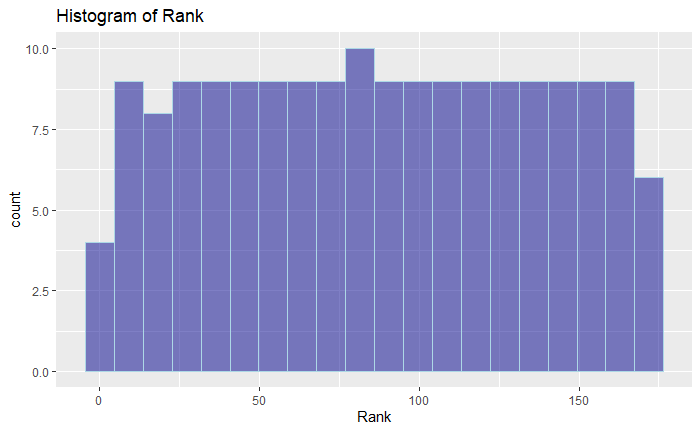

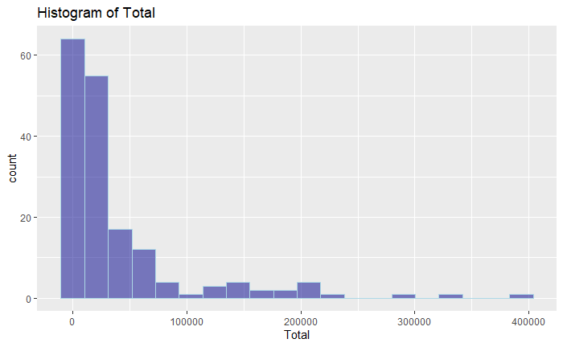

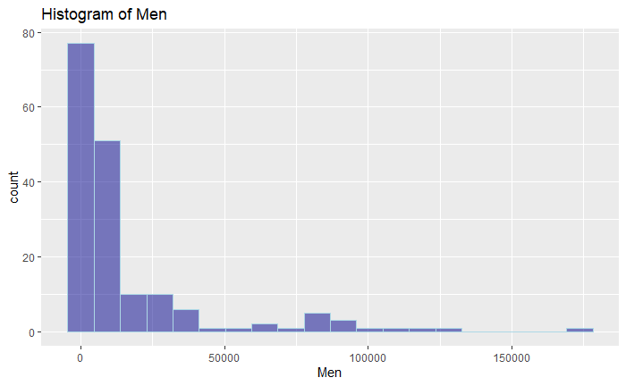

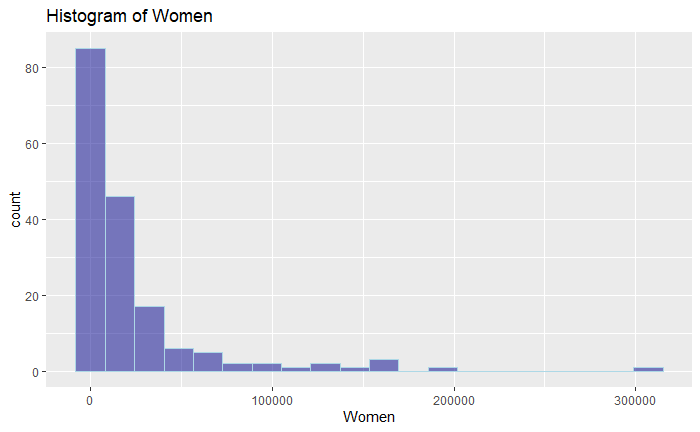

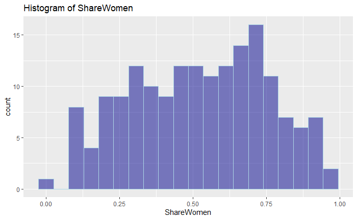

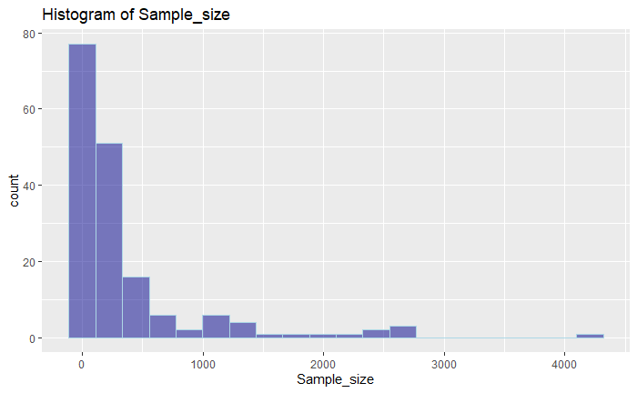

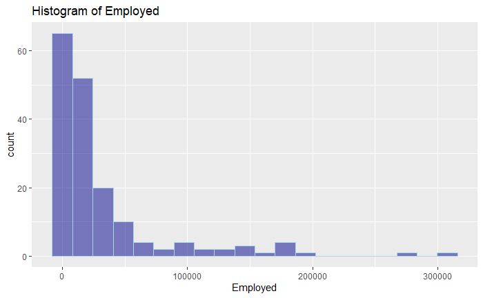

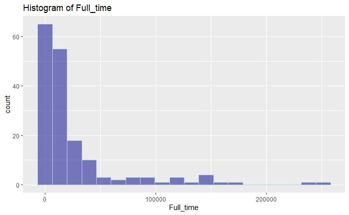

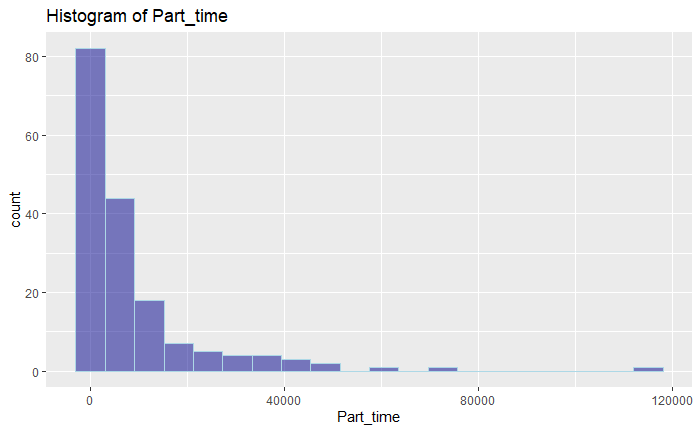

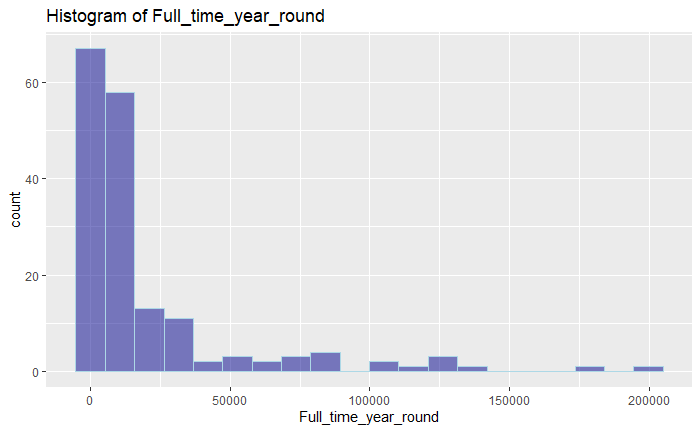

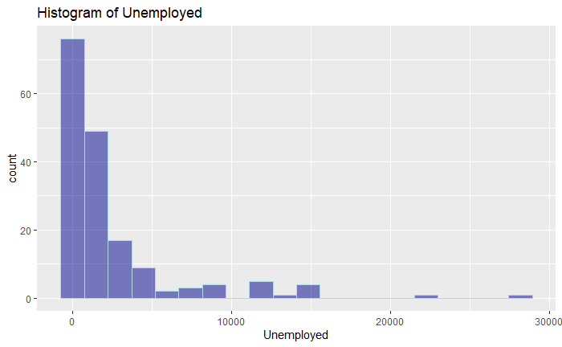

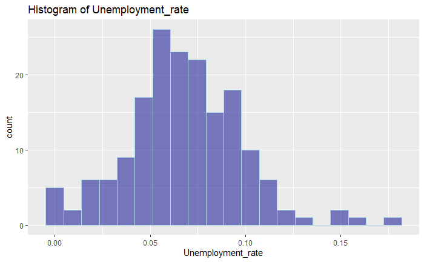

[6 more figures not shown]

```r
for (var in colnames(select_if(df.clean, is.numeric)) ) {
    g = ggplot(df.clean) +
        geom_histogram( aes( unlist(df.clean[, var]) ), bins=20,
                        fill = "darkblue", color = "lightblue", alpha = 0.5) +
        labs( title = paste("Histogram of", var),
              x = var)
    plot(g)
}
```

And to be able to see outliers the boxplot will be our aproach.

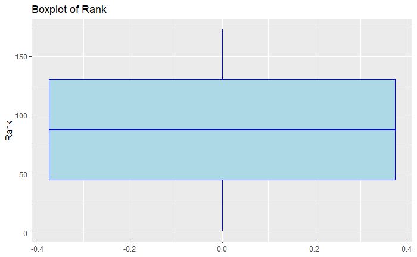

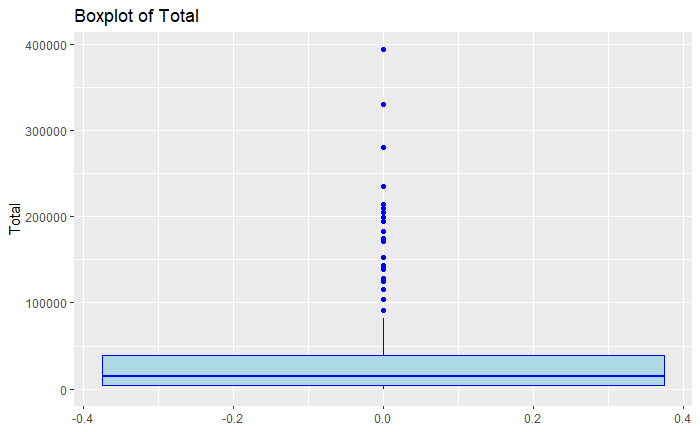

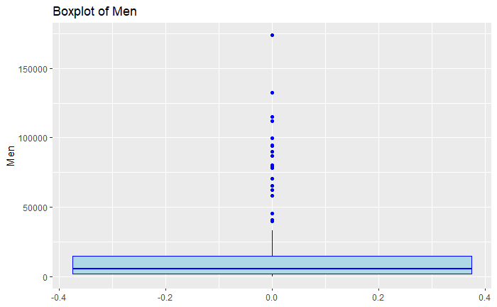

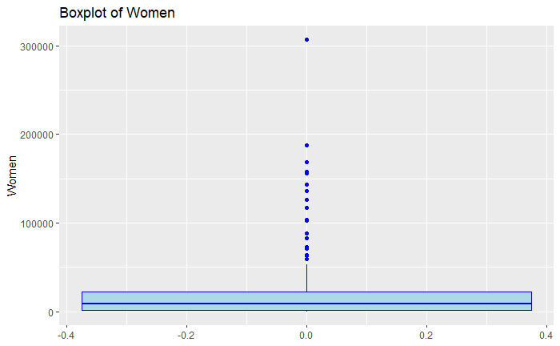

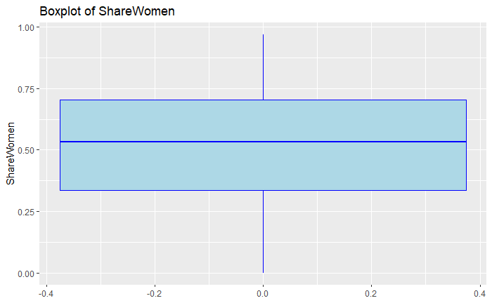

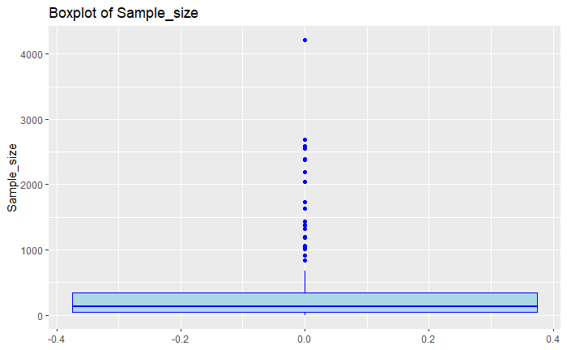

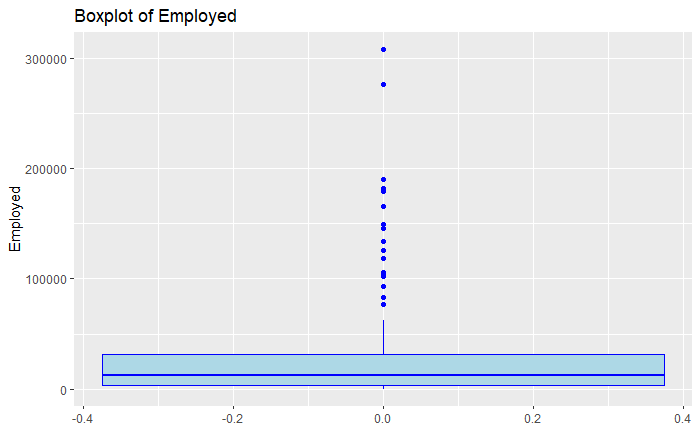

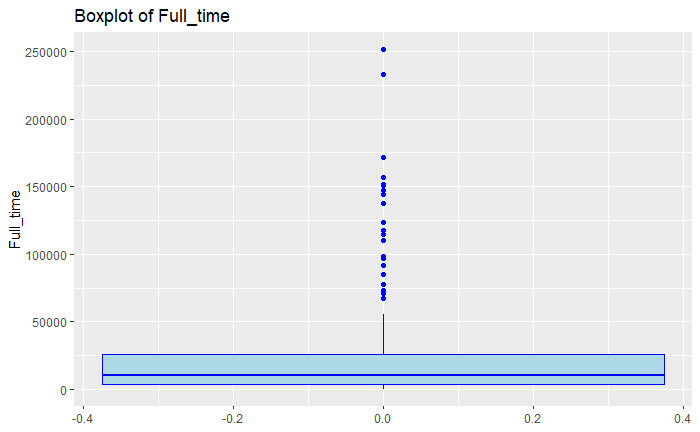

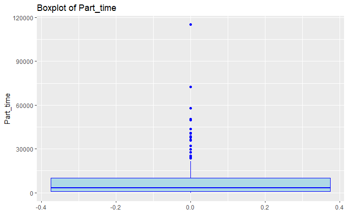

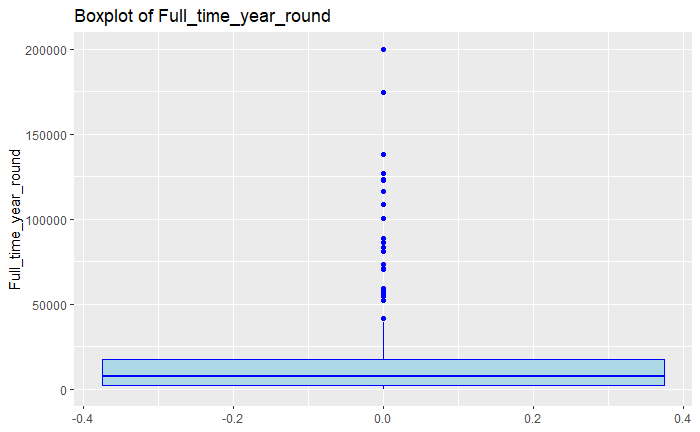

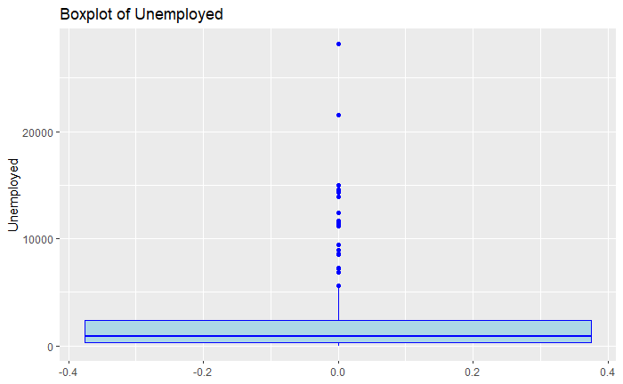

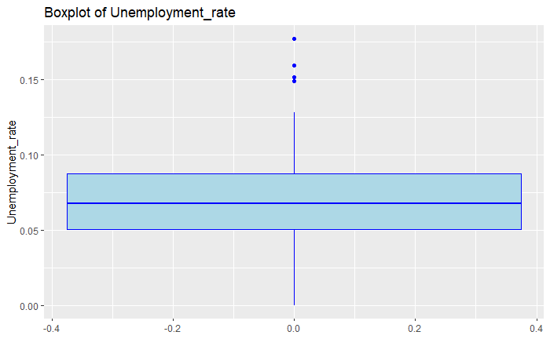

[6 more figures not shown]

```r
for ( var in colnames( select_if(df.clean, is.numeric) ) ) {
    g = ggplot(df.clean) +
        geom_boxplot( aes( y = unlist(df.clean[, var]) ),
                      fill = "lightblue", color = "blue") +
        labs(title = paste("Boxplot of", var),
             y = var)
    plot(g)
}
```

We can add a QQ plot as a visual indication of normality.

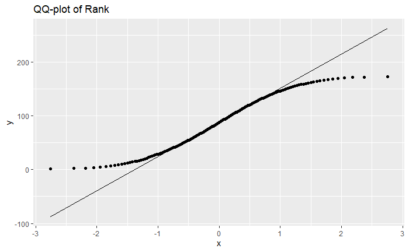

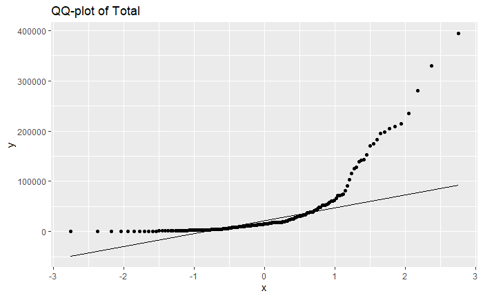

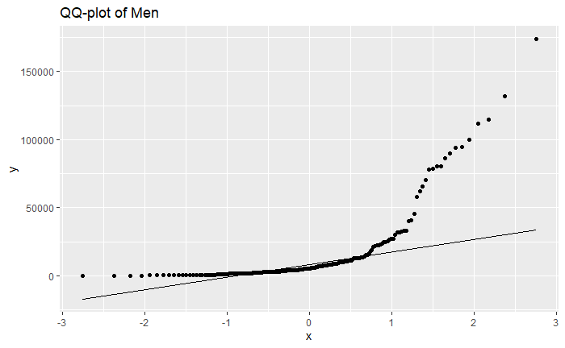

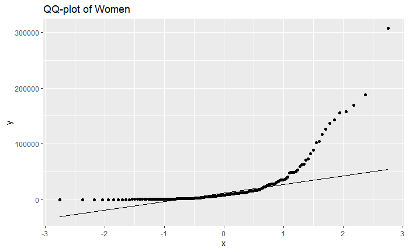

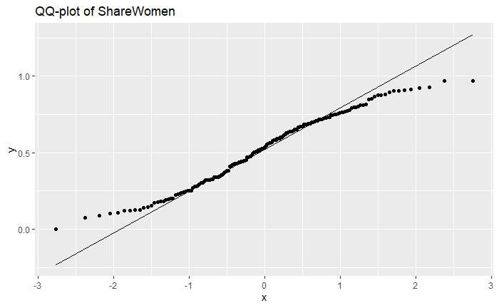

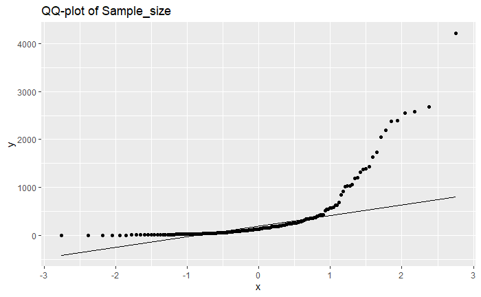

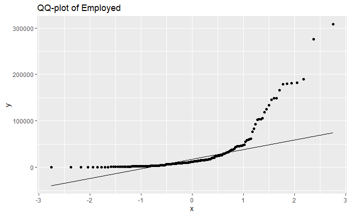

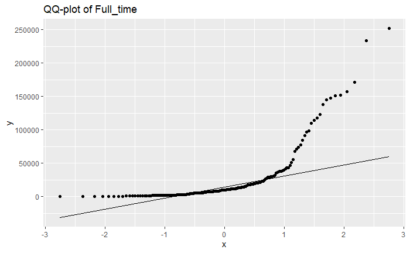

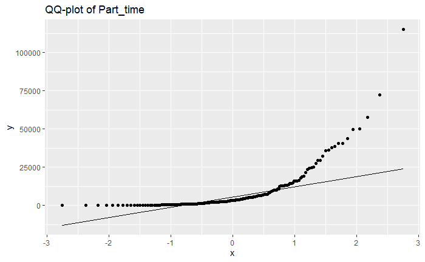

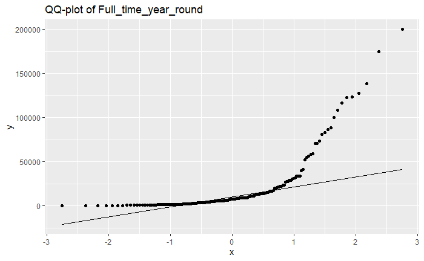

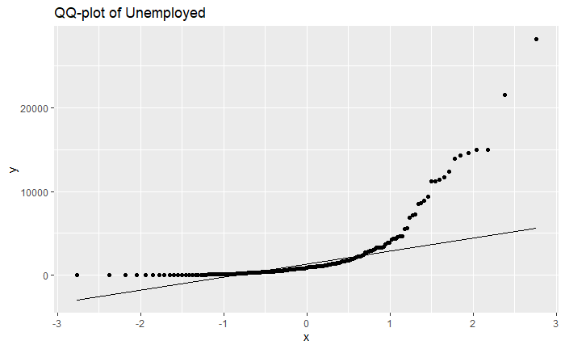

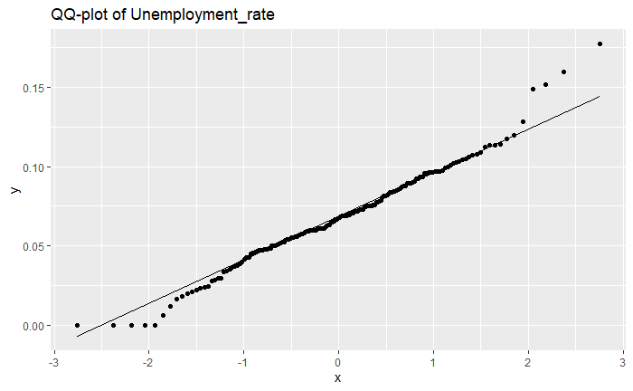

[6 more figures not shown]

```r
for (var in colnames( select_if(df.clean, is.numeric)) ) {
    g = ggplot(df.clean, aes( sample = unlist( df.clean[, var])) ) +
        stat_qq() +
        stat_qq_line() +
        labs( title = paste("QQ-plot of", var) )
    plot(g)
}
```

```r
norm.stats <- data.frame()
for (var in colnames( select_if( df.clean, is.numeric) ) ) {
    ks <- ks.test( unlist( df.clean[, var] ), y = pnorm)
    sh <- shapiro.test( unlist( df.clean[, var]) )
    vals <- data.frame(
        ks_test = sprintf("%6.5f" ,c(ks$p.value)),
        shapiro_test = sprintf("%6.5f", c(sh$p.value) ),
        row.names = var
    )
    norm.stats <- bind_rows(norm.stats, vals)
}
remove(ks)
remove(sh)
remove(vals)
norm.stats
```

|  | ks_test | shapiro_test |
| --- | --- | --- |
| Rank | 0.00000 | 0.00003 |
| Total | 0.00000 | 0.00000 |
| Men | 0.00000 | 0.00000 |
| Women | 0.00000 | 0.00000 |
| ShareWomen | 0.00000 | 0.00433 |
| Sample_size | 0.00000 | 0.00000 |
| Employed | 0.00000 | 0.00000 |
| Full_time | 0.00000 | 0.00000 |
| Part_time | 0.00000 | 0.00000 |
| Full_time_year_round | 0.00000 | 0.00000 |

[output cut: 8 more lines]

## 4.2 Multivariate Analysis

> In a project, the idea is to explore how the explanatory variables (X) affect the response variable (y).

Here we want to know how the variables affect to ‘unemployment_rate’. For this task could be useful the scatter-plot to see the pattern created when two variables are compared. And the correlation coefficient which tell us how much relation they have.

- `ggpairs()`: from `GGally` returns a matrix with scatterplot and correlations.

[output not shown]

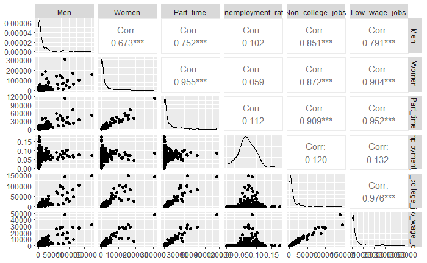

```r
df.clean %>%
    select(Men, Women, Part_time, Unemployment_rate,
           Non_college_jobs, Low_wage_jobs) %>%
    ggpairs()
```

There are only select some variables, it have been discarded the character ones and cherry-pick variables with some correlation. The full correlation matrix could not be seen.

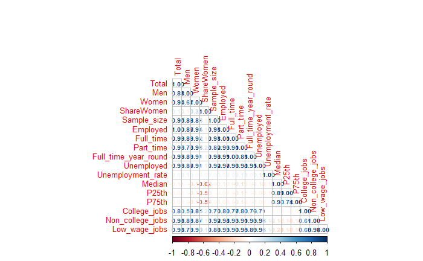

```r
corrs <- round( cor(df.clean[, -c(1, 2, 3, 7)]), 3)
corrplot (corrs, method = "number", type = "lower",
          tl.cex = 0.8, number.cex = 0.6)
```

Looking into ‘Unemployment_rate’ the correlations are so lightly, in this case a linear regression would not be the best approach.

When two explanatory variables have high correlations means both variables can explain the same variance in the target variable, creating redundancy and making it more difficult to determine the effect of each individual explanatory feature. Then, it must be eliminated before modeling.

## 4.3 Exploring

When we want to explore more deeply the dataset we can start doing questions and looking for answers:

- What are the top 10 majors with the lower unemployment rate?
- And with the higher unemployment rate?
- What are the majors with more specialized jobs (requiring college)?
- What are the best median-value-paying jobs?
- Do the majors with more share of women enrolled have a higher or lower unemployed rate?
- Do the majors with more share of women have higher rate of part time workers?
- Do the majors with a greater share of women enrolled have a similar salary median?

#### What are the top 10 majors with the lower unemployment rate?

```r
# Selecting top 10
top10.hig.emp <- df.clean %>%
  select(Major, Unemployment_rate) %>%
  arrange( desc(Unemployment_rate) ) %>%
  head(10)

# Selecting top 10
top10.low.emp <- df.clean %>%
  select(Major, Unemployment_rate) %>%
  arrange( Unemployment_rate ) %>%
  head(10)
top10.low.emp
```

| Major | Unemployment_rate |
| --- | --- |
| MATHEMATICS AND COMPUTER SCIENCE | 0.000000 |
| MILITARY TECHNOLOGIES | 0.000000 |
| BOTANY | 0.000000 |
| SOIL SCIENCE | 0.000000 |
| EDUCATIONAL ADMINISTRATION AND SUPERVISION | 0.000000 |
| ENGINEERING MECHANICS PHYSICS AND SCIENCE | 0.006334 |
| COURT REPORTING | 0.011690 |
| MATHEMATICS TEACHER EDUCATION | 0.016203 |
| PETROLEUM ENGINEERING | 0.018381 |
| GENERAL AGRICULTURE | 0.019642 |

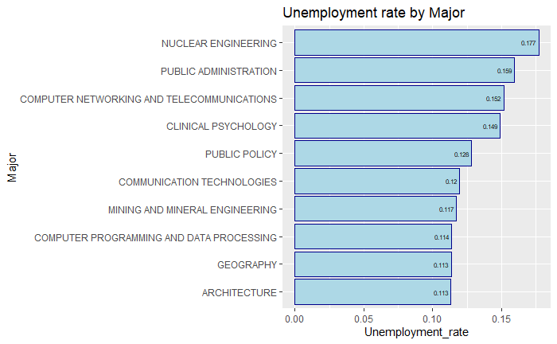

```r
# plot top 10 higher Unemployment rate
ggplot(top10.hig.emp) +
  geom_col( aes(x = Unemployment_rate,
                y = reorder( Major, +Unemployment_rate) ),
            color = "darkblue", fill = "lightblue" ) +
  labs( y = "Major" ) +
  geom_text( aes( x = Unemployment_rate,
                  y = Major, label = round(Unemployment_rate, 3) ),
             size = 2, hjust = 1.2) +
  ggtitle("Unemployment rate by Major")
```

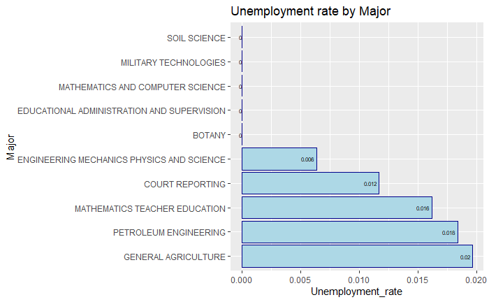

```r
# plot top 10 lower Unemployment rate
ggplot(top10.low.emp) +
  geom_col( aes(x = Unemployment_rate,
                y = reorder( Major, -Unemployment_rate) ),
            color = "darkblue", fill = "lightblue" ) +
  labs( y = "Major" ) +
  geom_text( aes( x = Unemployment_rate,
                  y = Major, label = round(Unemployment_rate, 3) ),
             size = 2, hjust = 1.2) +
  ggtitle("Unemployment rate by Major")
```

The first graph of the top 10 unemployment rate looks fine but the second one not at all. Let’s try the same but using the proportion of total employees for ordering the data within unemployment rate.

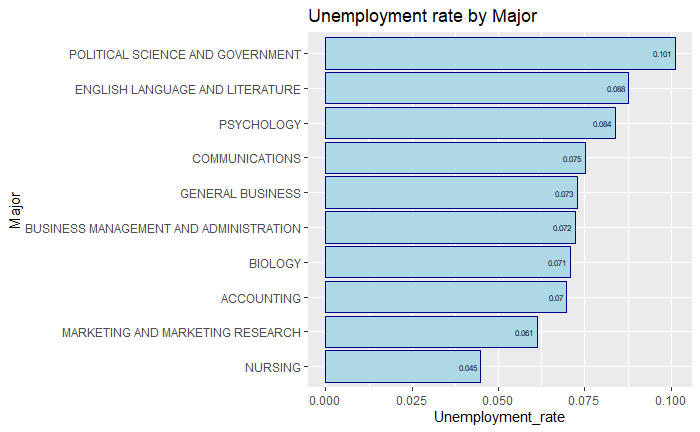

```r
top10.hig.prop <- df.clean %>%
  mutate (prop = Total / sum(Total) ) %>%
  select (Major, Unemployment_rate, prop) %>%
  arrange(desc(prop), desc(Unemployment_rate)) %>%
  head(10)

# plot top 10 higher Unemployment rate by proportion
ggplot(top10.hig.prop) +
  geom_col( aes(x = Unemployment_rate,
                y = reorder( Major, +Unemployment_rate) ),
            color = "darkblue", fill = "lightblue" ) +
  labs( y = "Major" ) +
  geom_text( aes( x = Unemployment_rate,
                  y = Major, label = round(Unemployment_rate, 3) ),
             size = 2, hjust = 1.2) +
  ggtitle("Unemployment rate by Major")
```

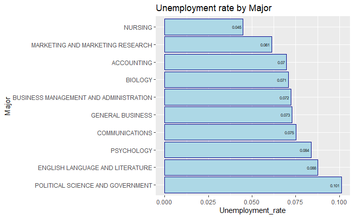

```r
top10.low.prop <- df.clean %>%
  mutate (prop = Total / sum(Total) ) %>%
  select (Major, Unemployment_rate, prop) %>%
  arrange(desc(prop), Unemployment_rate) %>%
  head(10)

# plot top 10 lower Unemployment rate by proportion
ggplot(top10.low.prop) +
  geom_col( aes(x = Unemployment_rate,
                y = reorder( Major, -Unemployment_rate) ),
            color = "darkblue", fill = "lightblue" ) +
  labs( y = "Major" ) +
  geom_text( aes( x = Unemployment_rate,
                  y = Major, label = round(Unemployment_rate, 3) ),
             size = 2, hjust = 1.2) +
  ggtitle("Unemployment rate by Major")
```

It would not be necessary the second visualization, It have the same values because it is ordered by proportion. It show the most popular majors ordered by employment rate, and nursing with the best rate.

#### More specialized jobs

Just like the last time, we are going to need new columns such as proportions of college jobs:

```r
df.clean <- df.clean %>%
  mutate ( College_jobs_pct = College_jobs / (College_jobs + Non_college_jobs),
           Employees_pct = Total / sum(Total) )
```

```r
df.clean %>%
  select(Major_category, Major, College_jobs_pct) %>%
  group_by(Major_category) %>%
  summarize(mean_college_jobs_pct = mean(College_jobs_pct)) %>%
  arrange(desc(mean_college_jobs_pct))
```

| Major_category | mean_college_jobs_pct |
| --- | --- |
| Education | 0.7137 |
| Engineering | 0.6799 |
| Computers & Mathematics | 0.6044 |
| Biology & Life Science | 0.5933 |
| Interdisciplinary | 0.5701 |
| Physical Sciences | 0.5317 |
| Health | 0.5161 |
| Psychology & Social Work | 0.5080 |
| Agriculture & Natural Resources | 0.4056 |
| Humanities & Liberal Arts | 0.3855 |

[output cut: 6 more lines]

#### Best median-value-paying jobs

First we have to add a variable for median salaries grouped by major category, and then use that to generate a boxplot visualization for comparison.

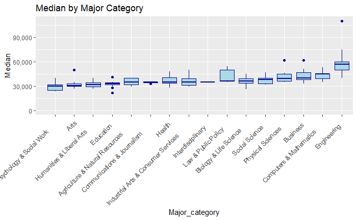

```r
df.clean <- df.clean %>%
  group_by(Major_category) %>%
  mutate( Salary_mdn = median(Median) )

ggplot(data = df.clean) +
  geom_boxplot( aes( x = reorder(Major_category, Salary_mdn),
                     y = Median),
                fill = "lightblue", color = "darkblue") +
  labs( x = "Major_category" ) +
  ggtitle ("Median by Major Category") +
  theme( axis.text.x = element_text( angle = 45, hjust = 1.2 ) ) +
  expand_limits( x = c(0, NA), y = c(0, NA) ) +
  scale_y_continuous( labels = scales::comma )
```

We can observe that Engineering, Maths, Business, Physics are the top paying jobs.

Other approaching is to do multiple comparison (post-hoc) of the median.

```r
pairwise.wilcox.test(df.clean$Median, df.clean$Major_category, p.adjust.method = "holm") %>% suppressWarnings()
```

```
    Pairwise comparisons using Wilcoxon rank sum test with continuity correction

data:  df.clean$Median and df.clean$Major_category

                                    Agriculture & Natural Resources Arts
Arts                                1.000                           -
Biology & Life Science              1.000                           1.000
Business                            0.801                           0.352
Communications & Journalism         1.000                           1.000
Computers & Mathematics             0.295                           0.542
Education                           1.000                           1.000
Engineering                         0.002                           0.007
Health                              1.000                           1.000
Humanities & Liberal Arts           1.000                           1.000
Industrial Arts & Consumer Services 1.000                           1.000
Interdisciplinary                   1.000                           1.000
Law & Public Policy                 1.000                           1.000
Physical Sciences                   1.000                           0.759
Psychology & Social Work            1.000                           1.000
Social Science                      1.000                           1.000
                                    Biology & Life Science Business
Arts                                -                      -
Biology & Life Science              -                      -
Business                            0.884                  -
Communications & Journalism         1.000                  0.988
Computers & Mathematics             0.451                  1.000
Education                           0.428                  0.008
Engineering                         0.000066               0.042
Health                              1.000                  1.000
Humanities & Liberal Arts           0.367                  0.007
Industrial Arts & Consumer Services 1.000                  1.000
Interdisciplinary                   1.000                  1.000
Law & Public Policy                 1.000                  1.000
Physical Sciences                   1.000                  1.000
Psychology & Social Work            0.884                  0.063
Social Science                      1.000                  1.000
                                    Communications & Journalism Computers & Mathematics
Arts                                -                           -
Biology & Life Science              -                           -
Business                            -                           -
```

[output cut: 63 more lines]

```
Business                            -
Communications & Journalism         -
Computers & Mathematics             -
Education                           -
Engineering                         -
Health                              -
Humanities & Liberal Arts           -
Industrial Arts & Consumer Services -
Interdisciplinary                   -
Law & Public Policy                 -
Physical Sciences                   -
Psychology & Social Work            -
Social Science                      0.775

P value adjustment method: holm
```

On the last output we look for p < 0.05 meaning there are differences between the medians of that groups. With the boxplot we can see which are greater visually but with these comparisons we can actually know which is greater than another statistically.

#### Relatioship between Majors with more share of women and unemployed rate

This task should be do it with correlations, and then we can plot to see its graphic representations.

```r
#cor(df.clean$ShareWomen, df.clean$Unemployment_rate, method = "pearson")

cor(df.clean$ShareWomen, df.clean$Unemployment_rate,
    method = "spearman")
```

```
[1] 0.0663
```

The spearman correlation is non-parametric and it is suitable for when the relationship of two variables are non-linear, or do not follow the norm distribution.

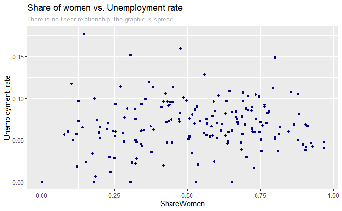

```r
ggplot( data = df.clean ) +
  geom_point( aes( x = ShareWomen, y = Unemployment_rate ),
              color = "darkblue") +
  ggtitle ("Share of women vs. Unemployment rate") +
  labs ( subtitle = "There is no linear relationship, the graphic is spread", color = "darkgray", size = 8) +
  theme( plot.subtitle = element_text( color = "darkgray",
                                               size = 10) )
```

#### Do the majors with more share of women have higher rate of part time workers?

Just like the last question, we can see the relationship of this two variables with a correlation.

```r
cor(df.clean$ShareWomen, df.clean$Part_time, method = "spearman")
```

```
[1] 0.3348
```

It can be seen a medium-slight positive correlation between both Share of woman enrolled and workers with part time contract. This is how looks like the correlation:

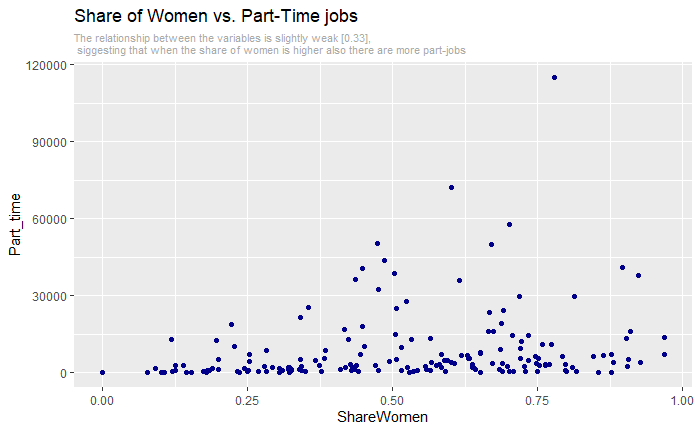

```r
ggplot(data = df.clean) +
    geom_point( aes( x = ShareWomen, y = Part_time),
                color = "darkblue") +
    labs( title = "Share of Women vs. Part-Time jobs",
          subtitle = "The relationship between the variables is slightly weak [0.33],\n siggesting that when the share of women is higher also there are more part-jobs") +
    theme( plot.subtitle = element_text( color = "darkgray", size = 8) )
```

#### Majors with a greater share of women and salary median

```r
cor(df.clean$ShareWomen, df.clean$Median)
```

```
[1] -0.6187
```

```r
cor(df.clean$ShareWomen, df.clean$Low_wage_jobs)
```

```
[1] 0.1878
```

The first correlation show when the greater is the share of women enrolled, the less are the Median salary; and in the second correlation, almost without strength if the share of women is high there are a slight relationship (almost none) with more low wage jobs.

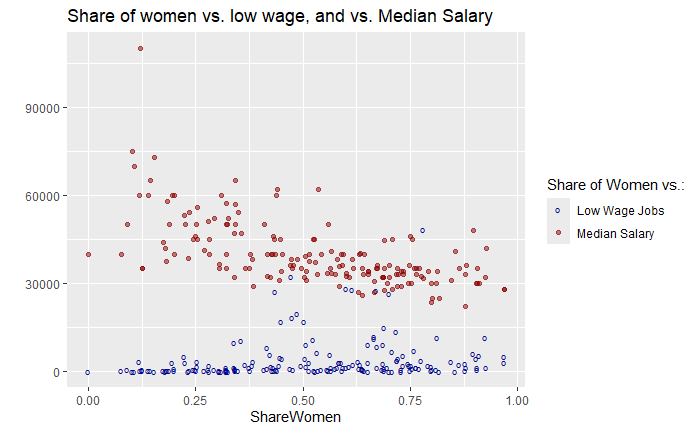

```r
ggplot(data = df.clean) +
    geom_point( aes( x = ShareWomen, y = Low_wage_jobs,
                     color = "Low Wage Jobs"),
                alpha = 1, shape = "o", size = 2) +
    geom_point( aes( x = ShareWomen, y = Median,
                     color = "Median Salary"), alpha = 0.5) +
    labs(title = "Share of women vs. low wage, and vs. Median Salary",
         y = "", color = "Share of Women vs.:") +
    scale_color_manual(values = c("Low Wage Jobs" = "darkblue",
                                  "Median Salary" = "darkred") ) +
    theme(legend.title = element_text())
```

The next step could be to test if the median of lower share of women is greater or not than higher share of women. To verify this we can run hypothesis tests. First we are going to add a column with two categories, one for higher share and other for lower share of women. Then we have to be sure which test we can use, for that we have to check the normality and if its fine, the homoscedasticity.

```r
df.clean <- df.clean %>%
    mutate( ShareWomen_cat = ifelse(ShareWomen > 0.5, "higher", "lower") )

df.higher.w <- df.clean %>%
    filter( ShareWomen_cat == "higher") %>%
    select( Major, Major_category, ShareWomen,
            ShareWomen_cat, Low_wage_jobs, Median)

df.lower.w <- df.clean %>%
    filter( ShareWomen_cat == "lower") %>%
    select( Major, Major_category, ShareWomen,
            ShareWomen_cat, Low_wage_jobs, Median)
```

```r
ks.test( df.higher.w$Low_wage_jobs, "pnorm") %>% suppressWarnings()
```

```
    Exact one-sample Kolmogorov-Smirnov test

data:  df.higher.w$Low_wage_jobs
D = 0.99, p-value = 0.000000000000001
alternative hypothesis: two-sided
```

```r
ks.test( df.lower.w$Low_wage_jobs, "pnorm" ) %>% suppressWarnings()
```

```
    Asymptotic one-sample Kolmogorov-Smirnov test

data:  df.lower.w$Low_wage_jobs
D = 0.95, p-value <0.0000000000000002
alternative hypothesis: two-sided
```

```r
ks.test( df.higher.w$Median, "pnorm" ) %>% suppressWarnings()
```

```
    Asymptotic one-sample Kolmogorov-Smirnov test

data:  df.higher.w$Median
D = 1, p-value <0.0000000000000002
alternative hypothesis: two-sided
```

```r
ks.test( df.lower.w$Median, "pnorm" ) %>% suppressWarnings()
```

```
    Asymptotic one-sample Kolmogorov-Smirnov test

data:  df.lower.w$Median
D = 1, p-value <0.0000000000000002
alternative hypothesis: two-sided
```

In the las output we show that every test was lower than 0.05 thus there are no normality on these groups. Let’s check homoscedasticity:

```r
with(df.clean, car::leveneTest(Median, ShareWomen_cat) )  %>% suppressWarnings()
```

```
Levene's Test for Homogeneity of Variance (center = median)
       Df F value    Pr(>F)
group   1    25.4 0.0000012 ***
      170
---
Signif. codes:  0 ‘***’ 0.001 ‘**’ 0.01 ‘*’ 0.05 ‘.’ 0.1 ‘ ’ 1
```

```r
with(df.clean, car::leveneTest(Low_wage_jobs, ShareWomen_cat) )  %>% suppressWarnings()
```

```
Levene's Test for Homogeneity of Variance (center = median)
       Df F value Pr(>F)
group   1    1.86   0.17
      170
```

The first result for Median on ShareWomen_cat levels have p < 0.05 then we reject the Null Hypothesis; nevertheless, the second result for Low_wage_jobs on ShareWomen_cat levels the p is 0.17, then we maintain the Null Hypothesis of Homogeneity of Variances.

Now we know that for compare Median we will need a robust test, but with Low_wage_jobs we might use t-test because the sample is greater than 50 and that will not affect so much the results.

```r
wilcox.test(df.higher.w$Median, df.lower.w$Median)
```

```
    Wilcoxon rank sum test with continuity correction

data:  df.higher.w$Median and df.lower.w$Median
W = 1142, p-value = 0.00000000000001
alternative hypothesis: true location shift is not equal to 0
```

```r
cat("Median of Higher Share Woman: ", median(df.higher.w$Median),
    "\nMedian of Lower Share Woman: ", median(df.lower.w$Median), "\n" )
```

```
Median of Higher Share Woman:  34000
Median of Lower Share Woman:  45000
```

```r
t.test(df.higher.w$Low_wage_jobs, df.lower.w$Low_wage_jobs)
```

```
    Welch Two Sample t-test

data:  df.higher.w$Low_wage_jobs and df.lower.w$Low_wage_jobs
t = 1.8, df = 170, p-value = 0.07
alternative hypothesis: true difference in means is not equal to 0
95 percent confidence interval:
 -162.2 3917.3
sample estimates:
mean of x mean of y
     4708      2831
```

For Median there are differences between the median of the groups, but for Low Wage seem like there are not differences between the mean of the groups with this sample.

```r
df.higher.samp <- df.higher.w %>%
    rep_sample_n( size = 1000, reps = 200, replace = TRUE ) %>%
    summarize( mu_Median = mean(Median),
               mu_Low_wage = mean(Low_wage_jobs) )

df.lower.samp <- df.lower.w %>%
    rep_sample_n( size = 1000, reps = 200, replace = TRUE ) %>%
    summarize( mu_Median = mean(Median),
               mu_Low_wage = mean(Low_wage_jobs) )
```

```r
shapiro.test(df.lower.samp$mu_Median)
```

```
    Shapiro-Wilk normality test

data:  df.lower.samp$mu_Median
W = 1, p-value = 0.8
```

```r
shapiro.test(df.higher.samp$mu_Median)
```

```
    Shapiro-Wilk normality test

data:  df.higher.samp$mu_Median
W = 0.99, p-value = 0.4
```

```r
shapiro.test(df.lower.samp$mu_Low_wage)
```

```
    Shapiro-Wilk normality test

data:  df.lower.samp$mu_Low_wage
W = 0.99, p-value = 0.2
```

```r
shapiro.test(df.higher.samp$mu_Low_wage)
```

```
    Shapiro-Wilk normality test

data:  df.higher.samp$mu_Low_wage
W = 1, p-value = 0.9
```

```r
t.test(df.higher.samp$mu_Median, df.lower.samp$mu_Median)
```

```
    Welch Two Sample t-test

data:  df.higher.samp$mu_Median and df.lower.samp$mu_Median
t = -379, df = 289, p-value <0.0000000000000002
alternative hypothesis: true difference in means is not equal to 0
95 percent confidence interval:
 -12464 -12336
sample estimates:
mean of x mean of y
    34606     47006
```

```r
t.test(df.higher.samp$mu_Low_wage, df.lower.samp$mu_Low_wage)
```

```
    Welch Two Sample t-test

data:  df.higher.samp$mu_Low_wage and df.lower.samp$mu_Low_wage
t = 85, df = 361, p-value <0.0000000000000002
alternative hypothesis: true difference in means is not equal to 0
95 percent confidence interval:
 1848 1935
sample estimates:
mean of x mean of y
     4718      2827
```

Both p-value are close to zero, thus we can reject the null hypothesis of t-test. Then we can say the groups mean are different with this sample.

> We can infer with 95% confidence that the majors with 50% or more of those enrolled being women have, on average, more low-wage jobs and less median salary.

```r
df.salary.w <- df.clean %>%
  group_by(ShareWomen_cat) %>%
  summarize(Salary_mean = mean(Median) )
```

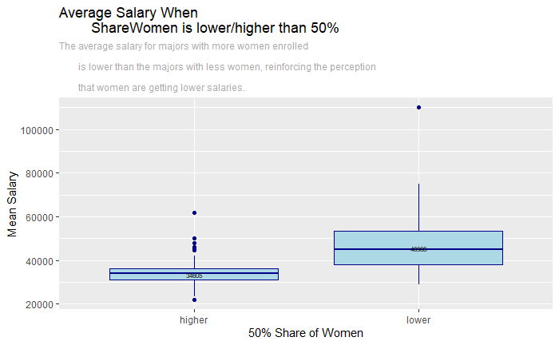

```r
ggplot( data = df.clean ) +
  geom_boxplot( aes( x = ShareWomen_cat, y = Median),
                fill = "lightblue", color = "darkblue" ) +
  labs( title = "Average Salary When
        ShareWomen is lower/higher than 50%",
        subtitle = "The average salary for majors with more women enrolled \n
        is lower than the majors with less women, reinforcing the perception \n
        that women are getting lower salaries.",
        x = "50% Share of Women",
        y = "Mean Salary" ) +
  geom_text( data = df.salary.w, aes( x = ShareWomen_cat,
                                      y = Salary_mean,
                                      label = round(Salary_mean)),
             size = 2.2, vjust = 1, color = "black" ) +
  theme(plot.subtitle = element_text( color = "darkgray", size = 9 ) )
```

```r
NA
```

To close this Exploratory Data Analysis we just need to compose the Analysis report.

# 5 Analysis Report

This Data Science project is about the EDA, composed of data wrangling and exploration to answer business questions and extract insights to support the decision-making process. When we write a Analysis Report we have to highlight the findings:

Dataset: College Majors (https://github.com/fivethirtyeight/data/tree/master/college-majors)

Dimensions: 173 observations, 21 variables

Data dictionary:

| Header | Type | Description |
| --- | --- | --- |
| `Rank` | Ordinal | Rank by median earnings |
| `Major_code` | Categorical | Major code, FO1DP in ACS PUMS |
| `Major` | Categorical | Major description |
| `Major_category` | Categorical | Category of major from Carnevale et al |
| `Total` | Numeric | Total number of people with major |
| `Sample_size` | Numeric | Sample size (unweighted) of full-time, year-round ONLY (used for earnings) |
| `Men` | Numeric | Male graduates |
| `Women` | Numeric | Female graduates |
| `ShareWomen` | Numeric | Women as share of total |
| `Employed` | Numeric | Number employed (ESR == 1 or 2) |
| `Full_time` | Numeric | Employed 35 hours or more |
| `Part_time` | Numeric | Employed less than 35 hours |
| `Full_time_year_round` | Numeric | Employed at least 50 weeks (WKW == 1) and at least 35 hours (WKHP >= 35) |
| `Unemployed` | Numeric | Number unemployed (ESR == 3) |
| `Unemployment_rate` | Numeric | Unemployed / (Unemployed + Employed) |
| `Median` | Numeric | Median earnings of full-time, year-round workers |
| `P25th` | Numeric | 25th percentile of earnings |
| `P75th` | Numeric | 75th percentile of earnings |
| `College_jobs` | Numeric | Number with job requiring a college degree |
| `Non_college_jobs` | Numeric | Number with job not requiring a college degree |
| `Low_wage_jobs` | Numeric | Number in low-wage service jobs |

Missing Data: There is one observation with missing data on Men, Women, ShareWomen and Total variables. The Major with this missing observation is FOOD SCIENCE (code: 1104).

## Report

EDA of a complete dataset, the missing values are less than 1% which was excluded to preserve the original data only without adding calculated numbers.

The descriptive statistics show high variances due to the presence of outliers. The women in college represents the 52%. The unemployment rate is around 6% presenting high variance.